# Workshop 1: Cleaning Data Example

Jeff Rouder & Julia Haaf

May 25th

Lexical Distance Effect: Are digits stored in an analog fashion. If so, it might be harder to say 4 is less than 5 than 2 is less than 5. If they are stored propositionally, then maybe the distance from 5 wouldn’t matter.

We are going to analyze a set of data at https://github.com/PerceptionCognitionLab/data0/tree/master/lexDec-dist5

# Loading Data

Let’s read in the data from the web. I am going to use read.table(). Function read.table() is for text files; function read.csv() is for csv files. R has other capabilities too including reading form databases, excel, SPSS, and SAS.

The following line reads data from the web and assigns it as a data.frame to indat

```r
indat <- read.table(url('https://raw.githubusercontent.com/PerceptionCognitionLab/data0/master/lexDec-dist5/ld5.all'))
```

We can check that indat is a data.frame. Data.frames are the main object for data. Use them liberally.

```r
is.data.frame(indat)
```

```
## [1] TRUE
```

We can see how big indat is

```r
dim(indat)
```

```
## [1] 19440     7
```

That is 19,440 rows and 7 columns

What are the columns of indat?

```r
colnames(indat)
```

```
## [1] "V1" "V2" "V3" "V4" "V5" "V6" "V7"
```

These are awkward. Let’s rename the columns by using the info https://github.com/PerceptionCognitionLab/data0/blob/master/lexDec-dist5/ld5.txt

```r
colnames(indat)=c('sub','block','trial','stim','resp','rt','error')
```

and we can look at the first 10 data points

```r
indat[1:10,]
```

```
##    sub block trial stim resp   rt error
## 1    0     0     0    4    1 4282     0
## 2    0     0     1    4    1  542     0
## 3    0     0     2    5    1  515     0
## 4    0     0     3    1    0  476     0
## 5    0     0     4    3    1  482     0
## 6    0     0     5    5    1  432     0
## 7    0     0     6    5    1  435     0
## 8    0     0     7    5    1  428     0
## 9    0     0     8    0    0  464     0
## 10   0     0     9    0    0  406     0
```

# Cleaning Data

1. People should be very good at this task. After all, how hard is it to say $2<5$ or $7>5$ ?
2. RTs should not be less than 250 ms, that is just too fast. They jumped the gun.
3. RTs should not be greater than 2000 ms. They sneezed, or texted, or had a brain fart.
4. Errors. We are not interested in the RTs for errors. Who knows what happened?
5. What about practice effects? It takes some time to learn the keys.

```r
mean(indat$err)
```

```
## [1] 0.02145062
```

How about by person? Here is where we use tapply. The function tapply is about as handy as it gets.

```r
tapply(indat$err,indat$sub,mean)
```

```
##           0           1           2           3           4           5
## 0.019444444 0.016666667 0.013888889 0.055555556 0.036111111 0.013888889
##           6           7           8           9          10          11
## 0.011111111 0.008333333 0.022222222 0.000000000 0.008333333 0.011111111
##          12          13          14          15          16          17
## 0.033333333 0.022222222 0.002777778 0.000000000 0.030555556 0.008333333
##          18          19          20          21          22          23
## 0.011111111 0.000000000 0.022222222 0.016666667 0.011111111 0.030555556
##          24          25          26          27          28          29
## 0.008333333 0.002777778 0.008333333 0.008333333 0.013888889 0.047222222
##          34          35          36          37          38          39
## 0.147222222 0.000000000 0.036111111 0.005555556 0.013888889 0.027777778
##          40          41          42          43          44          45
## 0.027777778 0.008333333 0.011111111 0.119444444 0.033333333 0.013888889
##          46          47          48          49          50          51
## 0.005555556 0.016666667 0.030555556 0.011111111 0.019444444 0.030555556
##          52          53          54          55          56          58
## 0.027777778 0.022222222 0.025000000 0.022222222 0.000000000 0.008333333
```

Hmmm. That is hard to read. Let’s sort the output from smallest to largest.

```r
sort(tapply(indat$err,indat$sub,mean))
```

```
##           9          15          19          35          56          14
## 0.000000000 0.000000000 0.000000000 0.000000000 0.000000000 0.002777778
##          25          37          46           7          10          17
## 0.002777778 0.005555556 0.005555556 0.008333333 0.008333333 0.008333333
##          24          26          27          41          58           6
## 0.008333333 0.008333333 0.008333333 0.008333333 0.008333333 0.011111111
##          11          18          22          42          49           2
## 0.011111111 0.011111111 0.011111111 0.011111111 0.011111111 0.013888889
##           5          28          38          45           1          21
## 0.013888889 0.013888889 0.013888889 0.013888889 0.016666667 0.016666667
##          47           0          50           8          13          20
## 0.016666667 0.019444444 0.019444444 0.022222222 0.022222222 0.022222222
##          53          55          54          39          40          52
## 0.022222222 0.022222222 0.025000000 0.027777778 0.027777778 0.027777778
##          16          23          48          51          12          44
## 0.030555556 0.030555556 0.030555556 0.030555556 0.033333333 0.033333333
##           4          36          29           3          43          34
## 0.036111111 0.036111111 0.047222222 0.055555556 0.119444444 0.147222222
```

Should we worry?

Let’s look at subject 34’s response time data:

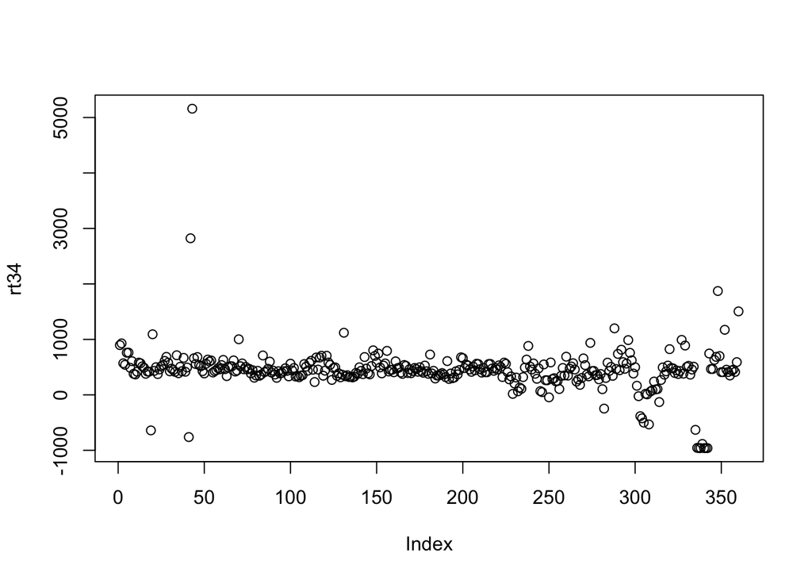

```r
rt34 <- indat$rt[indat$sub==34]
plot(rt34)
```

Let’s look at subject 15’s data for comparison:

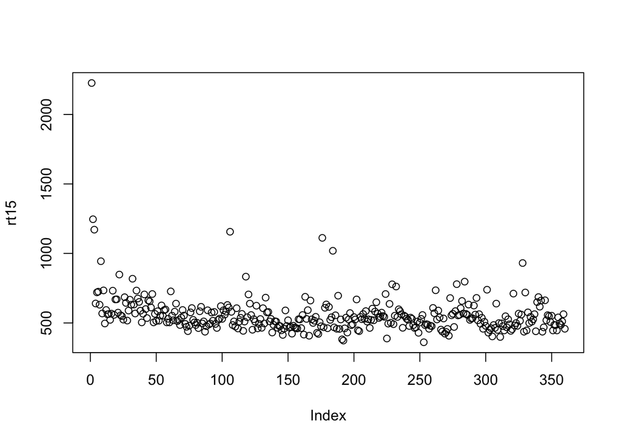

```r
rt15 <- indat$rt[indat$sub==15]
plot(rt15)
```

What about 43?

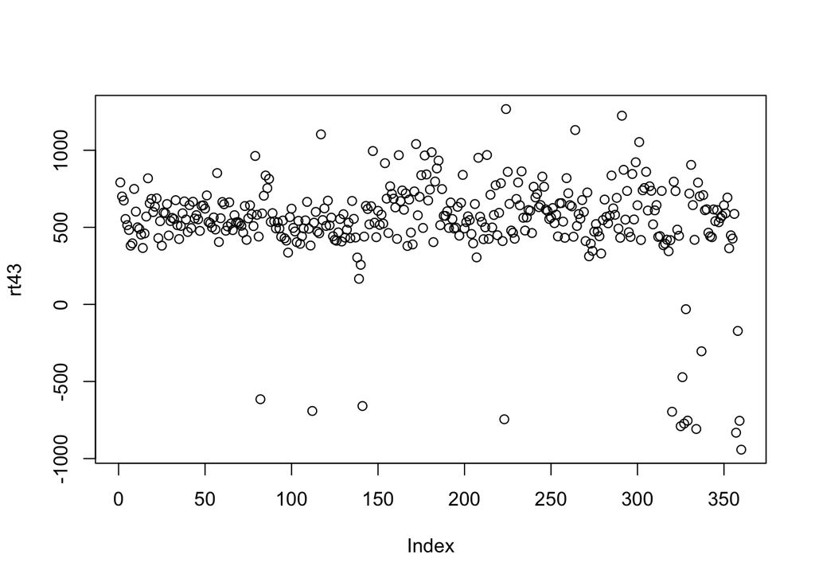

```r
rt43 <- indat$rt[indat$sub==43]
plot(rt43)
```

What about 3?

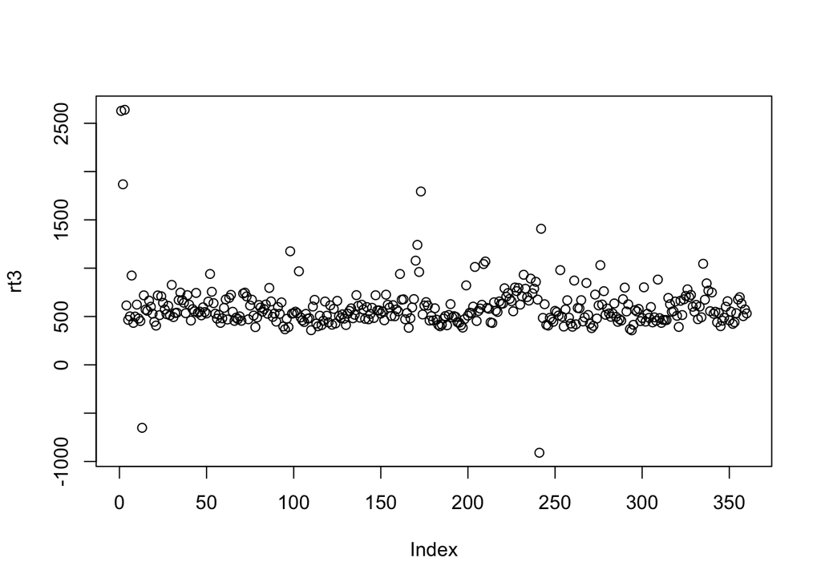

```r
rt3 <- indat$rt[indat$sub==3]
plot(rt3)
```

Mark 34 and 43 for deletion

```r
bad1 <- indat$sub%in%c(34,43)
```

Mark too-fast RTs

```r
bad2 <- indat$rt<250
mean(bad2)
```

```
## [1] 0.005606996
```

Let’s mark RTs over 2 sec for deletion

```r
bad3 <- indat$rt>2000
mean(bad3)
```

```
## [1] 0.006995885
```

Let’s mark errors for deletion

```r
bad4 <- indat$err==1
mean(bad4)
```

```
## [1] 0.02145062
```

Let’s look at learning. How about mean RT per block.

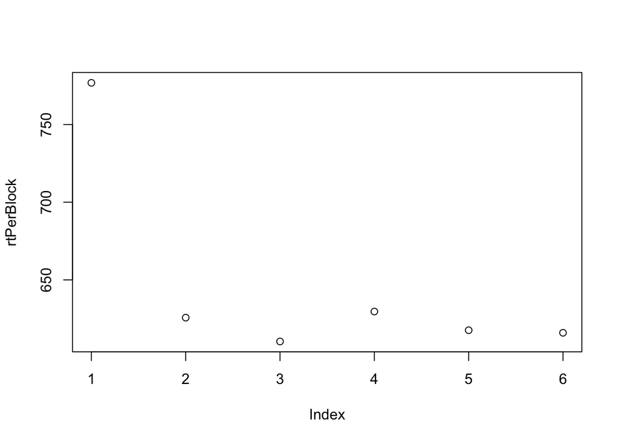

```r
rtPerBlock <- tapply(indat$rt,indat$block,mean)
plot(rtPerBlock)
```

First block is different. Let’s look at trials in the first block.

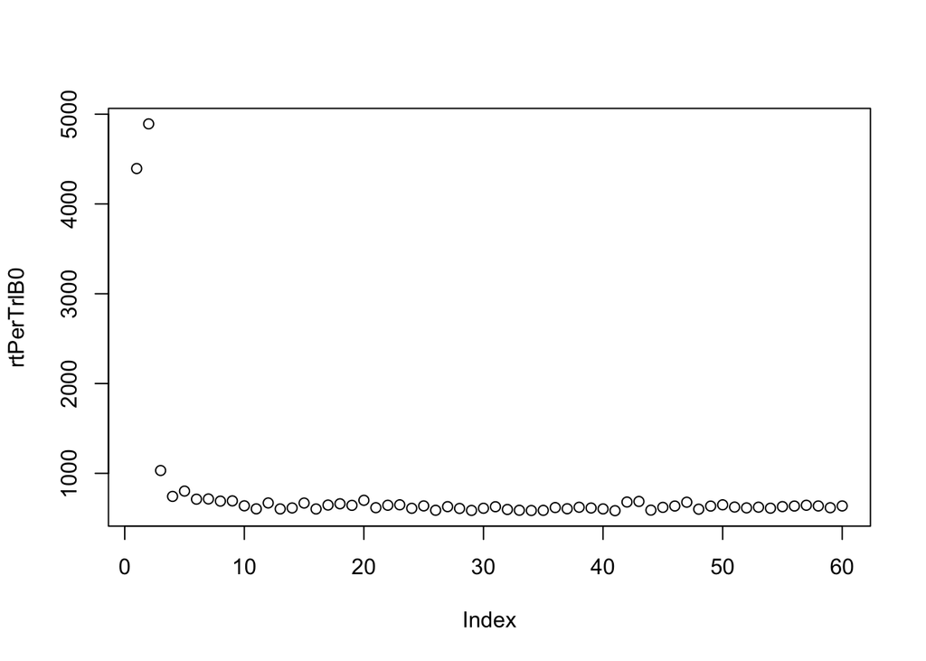

```r
include <- indat$block==0
rtPerTrlB0 <- tapply(indat$rt[include],indat$trial[include],mean)
plot(rtPerTrlB0)
```

OK, mark first 20 trials in block 0 for discard:

```r
bad5 <- indat$block==0 & indat$trial<20
```

Also, I find the first trial back from a break is slow. Let’s look at the remaining blocks:

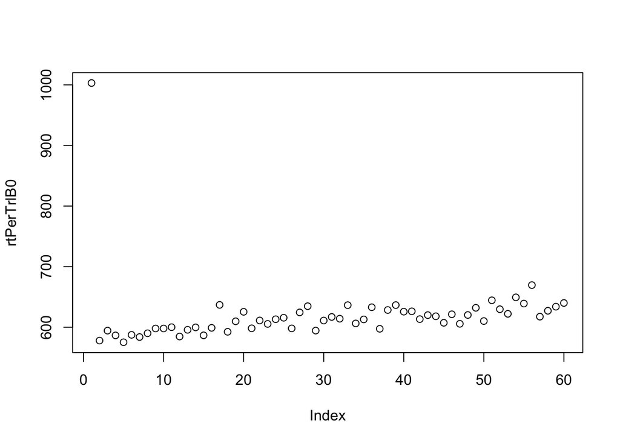

```r
include <- indat$block>0
rtPerTrlB0 <- tapply(indat$rt[include],indat$trial[include],mean)
plot(rtPerTrlB0)
```

OK, get rid of first trial back from break.

```r
bad6 <- indat$trial==0
```

Now, let’s include all bad trials and make a new data set without them:

```r
bad=bad1 | bad2 | bad3 |bad4 |bad5 | bad6
dat=indat[!bad,]
dim(dat)
```

```
## [1] 17031     7
```

Wow! We can keep a document like this that documents our decisions.

Here is the short version I might include with any analysis:

```r
cleanLD5=function()
{
indat=read.table(url('https://raw.githubusercontent.com/PerceptionCognitionLab/data0/master/lexDec-dist5/ld5.all'))
colnames(indat)=c('sub','block','trial','stim','resp','rt','error')

bad1=indat$sub%in%c(34,43)
bad2=indat$rt<250 | indat$rt>2000
bad3=indat$err==1
bad4=indat$block==0 & indat$trial<20
bad5=indat$trial==0
bad=bad1 | bad2 | bad3 |bad4 |bad5
dat=indat[!bad,]
return(dat)
}
```

# Analyzing Data

```r
dat=cleanLD5()
```

Let’s make a quick figure.

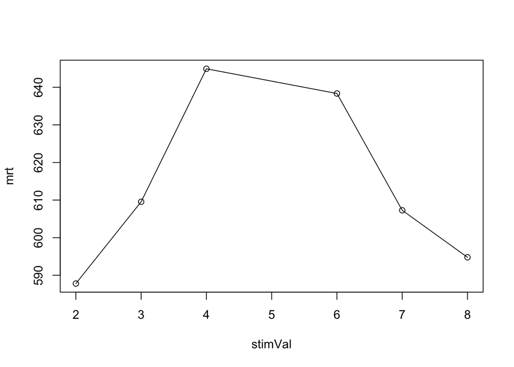

```r
mrt=tapply(dat$rt,dat$stim,mean)
stimVal=c(2:4,6:8)
plot(stimVal,mrt)
lines(stimVal,mrt)
```

A little cleaner:

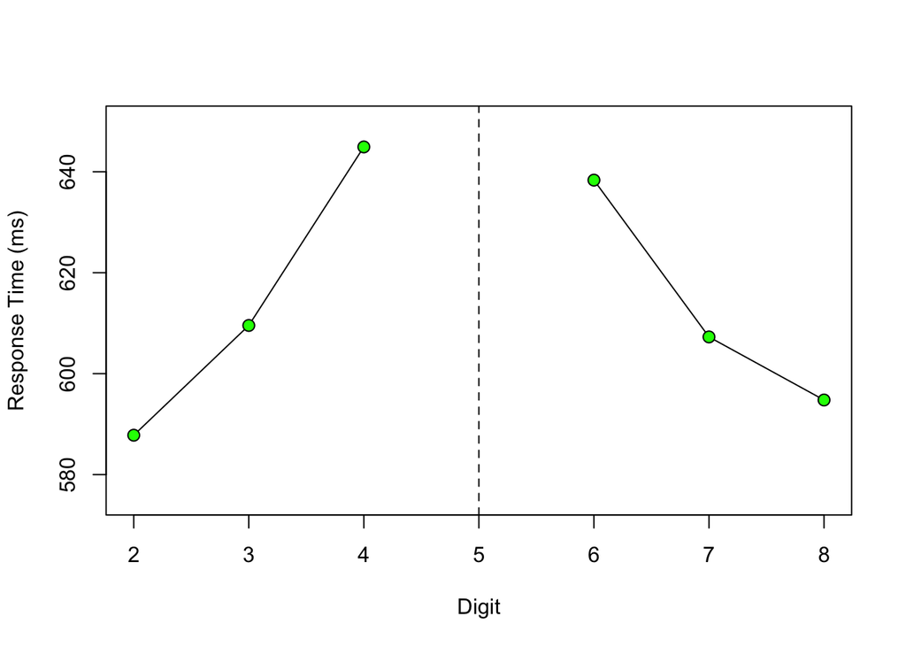

```r
plot(stimVal,mrt,typ='n',ylab="Response Time (ms)",xlab="Digit",ylim=c(575,650))
lines(stimVal[1:3],mrt[1:3])
lines(stimVal[4:6],mrt[4:6])
points(stimVal,mrt,pch=21,bg='green',cex=1.2)
abline(v=5,lty=2)
```